# Deskriptive Analyse

Das Payband “A” umfasst die Auszubildenden, von denen laut der Daten keiner das Unternehmen während der Ausbildung verlassen hat.

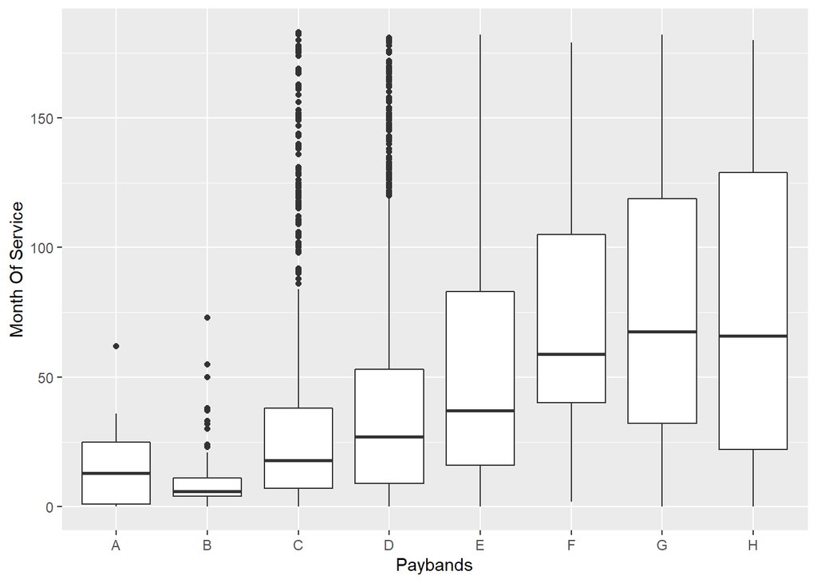

```r
ggplot(df, aes(Paybands, `Month Of Service`)) +
  geom_boxplot()
```

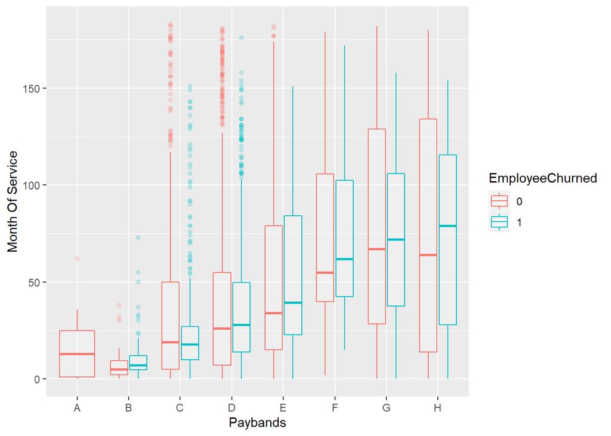

```r
ggplot(df, aes(Paybands, `Month Of Service`)) +
  geom_boxplot(aes(colour = EmployeeChurned), alpha=0.2)
```

Mitarbeitende in höheren Paybands zum Zeitpunkt der letzten Aktivität sind länger im Unternehmen, als in unteren. Mitarbeitende, die das Unternehmen verlassen haben, waren in fast allen Paybands länger im Unternehmen als die aktiven. Dies kann auch daran liegen, dass solche Positionen auch nachbesetzt werden müssen, zum Teil von extern oder es rücken Mitarbeitende nach.

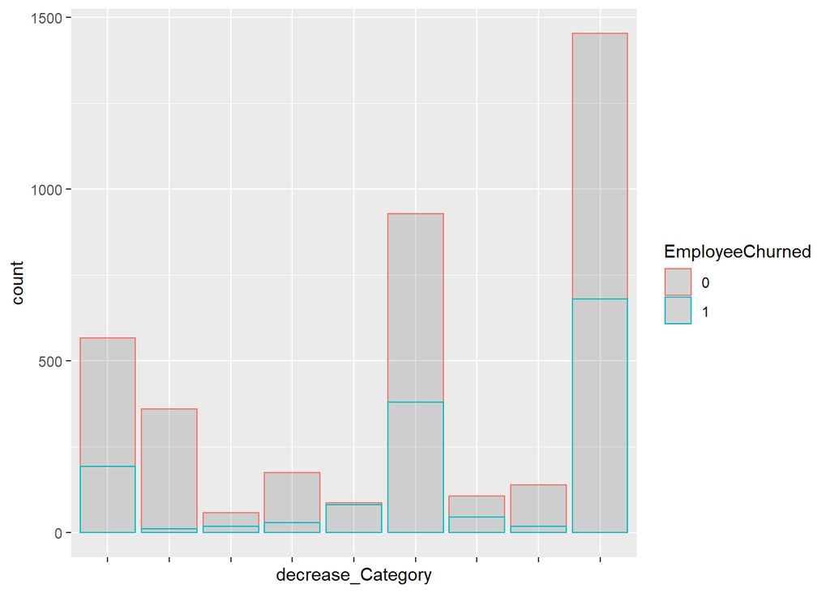

```r
ggplot(df, aes(decrease_Category)) +
  geom_bar(aes(colour = EmployeeChurned), alpha=0.2) +
  theme(axis.text.x=element_blank())
```

X-Achse: Customer GB Management GTU GD Human Resources GBS  
Other People  
Planning & Development Safety Supplier & Reporting

Aus dem Bereich GB Management verlassen wenige Mitarbeiter:innen das Unternehmen, was daran liegt, dass es sich eher um Senior-Positionen handelt und es eine neuere Einheit ist. Die geringe Abwanderung im Bereich Safety kann darauf zurückgeführt werden, dass es sich um eine relativ neue Einheit handelt.

“People” sowie “Supplier & Reporting” bilden die größten Bereiche.

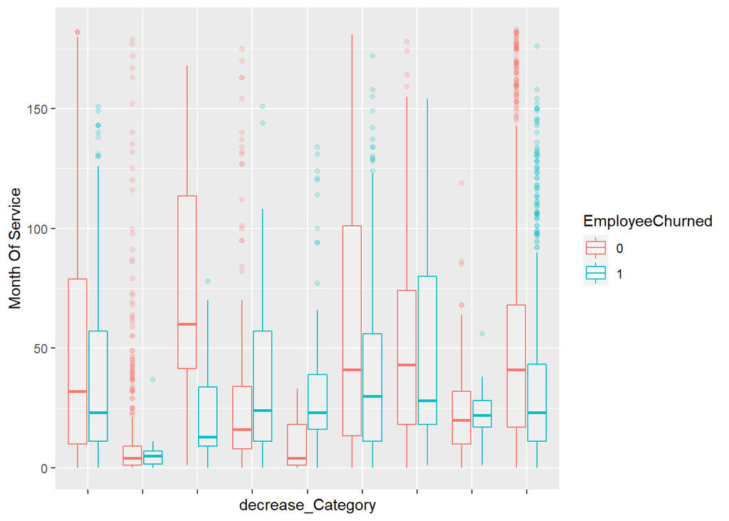

```r
ggplot(df, aes(decrease_Category, `Month Of Service`)) +
  geom_boxplot(aes(colour = EmployeeChurned), alpha=0.2)+
  theme(axis.text.x=element_blank())
```

X-Achse: Customer GB Management GTU GD Human Resources GBS  
Other People  
Planning & Development Safety Supplier & Reporting

```r
write_xlsx(df,"20220110_dataPrepped_beforeOneHot.xlsx")
```

Umwandeln qualitativer Merkmal in für die algorithmen lesbare dichotome Merkmale (0 und 1).

```r
hot_df <- one_hot(as.data.table(df))
write_xlsx(hot_df,"20220110_dataPrepped_afterOneHot.xlsx")
```